# Chemistry-Based Analysis: Sulfides, Selenides, and Tellurides

High CN Diagnosis & Weighted CN Analysis

crystract Workflow

2026-03-17

## 1. Introduction

This workflow performs a targeted, large-scale crystallographic analysis of Sulfides, Selenides, and Tellurides. By utilizing the Minimum Distance bonding algorithm within the highly parallelized `crystract` extraction pipeline, we calculate fundamental geometric metrics such as bond distances, bond angles, and coordination numbers (CN) across thousands of parsed `.cif` files.

Furthermore, this notebook introduces critical diagnostic steps to evaluate high-coordination environments (Geometric CN > 12) and to compute **Weighted Coordination Numbers**. Weighted CN provides a more accurate representation of the local chemical environment by taking into account crystallographic site occupancies and resolving partial occupancies inherent to structural disorder.

## 2. Setup: Libraries and Reference Data

We begin by loading the necessary data manipulation, crystallography, and parallel processing packages. A robust periodic table reference (`ptable`) is established to ensure all visualizations can accurately sort elements by their atomic number (Z) rather than alphabetically, exposing true periodic trends.

```r
# Data Manipulation
library(data.table)
library(stringr)
library(tidyr)
library(dplyr)

# Crystallography
library(crystract)

# Parallel Processing
library(future)
library(future.apply)

# Visualization
library(ggplot2)
library(forcats)
library(viridis)
library(gridExtra)
library(DT)      # For interactive tables
library(plotly)  # For interactive plots
library(scales)  # For plot scales and breaks

# --- Initialize Time Tracking ---
timing_log <- data.frame(
  Step = character(),
  Duration_Mins = numeric(),
  stringsAsFactors = FALSE
)

log_time <- function(step_name, start_time) {
  duration <- as.numeric(difftime(Sys.time(), start_time, units = "mins"))
  return(data.frame(Step = step_name, Duration_Mins = duration))
}

global_start <- Sys.time()

# --- ATOMIC NUMBER LOOKUP (For Sorting) ---
ptable <- data.table(
  Symbol = c("H","He","Li","Be","B","C","N","O","F","Ne",
             "Na","Mg","Al","Si","P","S","Cl","Ar","K","Ca",
             "Sc","Ti","V","Cr","Mn","Fe","Co","Ni","Cu","Zn",
             "Ga","Ge","As","Se","Br","Kr","Rb","Sr","Y","Zr",
             "Nb","Mo","Tc","Ru","Rh","Pd","Ag","Cd","In","Sn",
             "Sb","Te","I","Xe","Cs","Ba","La","Ce","Pr","Nd",
             "Pm","Sm","Eu","Gd","Tb","Dy","Ho","Er","Tm","Yb",
             "Lu","Hf","Ta","W","Re","Os","Ir","Pt","Au","Hg",
             "Tl","Pb","Bi","Po","At","Rn","Fr","Ra","Ac","Th",
             "Pa","U","Np","Pu","Am","Cm","Bk","Cf","Es","Fm"),
  Z = 1:100
)
```

## 3. Data Discovery and Chemistry Filtering

To analyze Chalcogenides strictly, our filtering logic is: **(Contains S OR Se OR Te) AND (Does NOT contain O)**. Excluding oxygen prevents the inclusion of sulfates, selenites, and tellurates, isolating the data strictly to sulfides, selenides, and tellurides.

```r
# --- Configuration ---
cif_directory <- "/Users/carnegieuser/Downloads/cif"

step_start <- Sys.time()

# --- 1. Get list of files ---
if (!dir.exists(cif_directory)) {
  warning("The specified directory does not exist. Please update 'cif_directory'.")
  all_cif_files <- character(0)
} else {
  all_cif_files <- list.files(cif_directory, pattern = "\\.cif$", full.names = TRUE)
}

if(length(all_cif_files) == 0) stop("No .cif files found.")

cat(sprintf("Found %d CIF files. Checking chemistry...\n", length(all_cif_files)))
```

```
## Found 21720 CIF files. Checking chemistry...
```

```r
# --- 2. Define Chemistry Filter Logic ---
check_chemistry <- function(file_path) {
  tryCatch({
    cif_content <- read_cif_files(file_path)[[1]]
    formula_str <- extract_chemical_formula(cif_content)
    if (is.na(formula_str)) return(FALSE)

    # Extract elements
    elements <- unique(stringr::str_extract_all(formula_str, "[A-Z][a-z]?")[[1]])

    # Criteria: Has S/Se/Te AND No Oxygen
    has_target <- any(c("S", "Se", "Te") %in% elements)
    has_oxygen <- "O" %in% elements

    return(has_target && !has_oxygen)
  }, error = function(e) return(FALSE))
}

# --- 3. Run Filter (Parallelized) ---
plan(multisession, workers = parallel::detectCores() - 1)
matches_mask <- future_sapply(all_cif_files, check_chemistry)
target_files <- all_cif_files[matches_mask]
plan(sequential)

timing_log <- rbind(timing_log, log_time("1. Filtering", step_start))
cat(sprintf("Filtering complete. Kept: %d files.\n", length(target_files)))
```

```
## Filtering complete. Kept: 1719 files.
```

## 4. Parallel Analysis (Optimized)

We run the `crystract` feature extraction using the `minimum_distance` bonding algorithm. This chunk expands the unit cell into a 3x3x3 supercell to ensure edge-atoms are correctly bonded to their periodic neighbors. A ghost filtering mechanism is also applied to handle duplicate distance measurements often created by crystallographic disorder.

```r
# --- Define Custom Radii Table ---
custom_radii_values <- data.table(
  Symbol = c("Ac", "Ag", "Al", "Am", "Ar", "As", "At", "Au", "B", "Ba",
             "Be", "Bi", "Br", "C", "Ca", "Cd", "Ce", "Cl", "Cm", "Co",
             "Cr", "Cs", "Cu", "Dy", "Er", "Eu", "F", "Fe", "Fr", "Ga",
             "Gd", "Ge", "H", "He", "Hf", "Hg", "Ho", "I", "In", "Ir",
             "K", "Kr", "La", "Li", "Lu", "Mg", "Mn", "Mo", "N", "Na",
             "Nb", "Nd", "Ne", "Ni", "Np", "O", "Os", "P", "Pa", "Pb",
             "Pd", "Pm", "Po", "Pr", "Pt", "Pu", "Ra", "Rb", "Re", "Rh",
             "Rn", "Ru", "S", "Sb", "Sc", "Se", "Si", "Sm", "Sn", "Sr",
             "Ta", "Tb", "Tc", "Te", "Th", "Ti", "Tl", "Tm", "U", "V",
             "W", "Xe", "Y", "Yb", "Zn", "Zr"),
  Radius = c(2.15, 1.45, 1.21, 1.8, 1.06, 1.19, 1.5, 1.36, 0.84, 2.15,
             0.96, 1.48, 1.2, 0.73, 1.76, 1.44, 2.04, 1.02, 1.69, 1.38,
             1.39, 2.44, 1.32, 1.92, 1.89, 1.98, 0.57, 1.42, 2.6, 1.22,
             1.96, 1.2, 0.31, 0.28, 1.75, 1.32, 1.92, 1.39, 1.42, 1.41,
             2.03, 1.16, 2.07, 1.28, 1.87, 1.41, 1.5, 1.54, 0.71, 1.66,
             1.64, 2.01, 0.58, 1.24, 1.9, 0.66, 1.44, 1.07, 2, 1.46,
             1.39, 1.99, 1.4, 2.03, 1.36, 1.87, 2.21, 2.2, 1.51, 1.42,
             1.5, 1.46, 1.05, 1.39, 1.7, 1.2, 1.11, 1.98, 1.39, 1.95,
             1.7, 1.94, 1.47, 1.38, 2.06, 1.6, 1.45, 1.9, 1.96, 1.53,
             1.62, 1.4, 1.9, 1.87, 1.22, 1.75),
  Type = "covalent"
)

set_radii_data(custom_radii_values)
```

```
## Custom radii table has been set for the current R session.
```

```r
cat("Custom radii table successfully loaded.\n")
```

```
## Custom radii table successfully loaded.
```

```r
analysis_output_dir <- "~/repos/ml-crystals/notebook/natural/crystract_chemistry_results"
num_workers <- parallel::detectCores() - 1

# --- Robust Worker Function ---
process_structure_robust <- function(file_path) {
  fname <- basename(file_path)

  tryCatch({
    # 1. Read and Extract
    cif_list <- read_cif_files(file_path)
    if(length(cif_list) == 0) return(NULL)
    cif_data <- cif_list[[1]]

    formula <- extract_chemical_formula(cif_data)
    atoms   <- extract_atomic_coordinates(cif_data, formula)
    metrics <- extract_unit_cell_metrics(cif_data)
    sym_ops <- extract_symmetry_operations(cif_data)

    if (is.null(atoms) || is.null(metrics) || is.null(sym_ops)) return(NULL)

    # 2. Transform and Expand (3x3x3 Supercell)
    full_cell <- apply_symmetry_operations(atoms, sym_ops, metrics, tolerance = 1e-4)
    expanded  <- expand_transformed_coords(full_cell, expansion_factors = c(1, 1, 1))

    # 3. Calculate Raw Distances
    dists <- calculate_distances(atoms, expanded, metrics, tolerance = 1e-4)
    if (nrow(dists) == 0) return(NULL)

    # --- 4. Attempt Ghost Filtering ---
    filter_status <- "applied"

    ghost_res <- tryCatch({
      filter_ghost_distances(dists, atoms, margin = 0.15, radii_type = "covalent")
    }, error = function(e) list(kept = data.table()))

    clean_dists <- ghost_res$kept

    # 5. Determine Bonds
    bonds <- minimum_distance(clean_dists, delta = 0.1)
    if (nrow(bonds) == 0) return(NULL)

    # 6. Calculate Properties
    cn_table <- calculate_neighbor_counts(bonds)
    angles   <- calculate_angles(bonds, atoms, expanded, metrics)

    # 7. Return Result
    data.table(
      file_name = fname,
      chemical_formula = formula,
      filter_status = filter_status, # Log status for diagnosis
      atomic_coordinates = list(atoms),
      expanded_coords = list(expanded),
      bonds_minimum_distance = list(bonds),
      angles_minimum_distance = list(angles),
      cn_minimum_distance = list(cn_table)
    )

  }, error = function(e) {
    return(NULL)
  })
}

# --- Execution Loop ---
step_start <- Sys.time()

if (length(target_files) > 0) {
  if (!dir.exists(analysis_output_dir)) dir.create(analysis_output_dir, recursive = TRUE)
  batch_size  <- 1000
  num_batches <- ceiling(length(target_files) / batch_size)

  plan(multisession, workers = num_workers)

  for (b in 1:num_batches) {
    idx_start <- (b - 1) * batch_size + 1
    idx_end   <- min(b * batch_size, length(target_files))
    batch_files <- target_files[idx_start:idx_end]

    cat(sprintf("Processing Batch %d of %d (%d files)...\n", b, num_batches, length(batch_files)))
    results_list <- future_lapply(batch_files, process_structure_robust, future.seed = TRUE)
    batch_dt <- rbindlist(results_list, fill = TRUE)

    if (nrow(batch_dt) > 0) {
      save_path <- file.path(analysis_output_dir, paste0("batch_", b, ".rds"))
      saveRDS(batch_dt, save_path)

      # Print filter stats for this batch
      stats <- table(batch_dt$filter_status)
      cat("  Filter Status:", paste(names(stats), stats, sep="=", collapse=", "), "\n")
    }
    rm(results_list, batch_dt); gc()
  }
  plan(sequential)
  timing_log <- rbind(timing_log, log_time("2. Analysis (Robust)", step_start))
} else {
  stop("No files passed the chemistry filter.")
}
```

```
## Processing Batch 1 of 2 (1000 files)...
```

```
##   Filter Status: applied=958
## Processing Batch 2 of 2 (719 files)...
```

```
##   Filter Status: applied=674
```

## 5. Data Processing: Aggregation & Diagnosis

In this aggregation step, we calculate the **Weighted Coordination Number**. A standard geometric calculation might count 6 distinct surrounding neighbor sites, yielding a geometric CN of 6. However, if those neighbor sites are highly disordered and each only has an occupancy of 0.5, the central atom effectively only “feels” 3 neighbors in the time-average bulk crystal. The Weighted CN multiplies geometric site counts by site occupancy to reveal the true environmental coordination.

```r
step_start <- Sys.time()

final_bonds_list <- list()
final_angles_list <- list()
high_cn_debug_log <- list()

if (dir.exists(analysis_output_dir)) {
  cat("Reading batch files and aggregating results...\n")
  batch_files <- list.files(analysis_output_dir, pattern = "^batch_\\d+\\.rds$", full.names = TRUE)

  for (bf in batch_files) {
    batch_dt <- readRDS(bf)

    for (i in 1:nrow(batch_dt)) {
      current_file <- batch_dt$file_name[i]
      if (is.null(batch_dt$bonds_minimum_distance) || length(batch_dt$bonds_minimum_distance) < i) next

      bonded_pairs <- batch_dt$bonds_minimum_distance[[i]]
      angles       <- batch_dt$angles_minimum_distance[[i]]
      coords       <- batch_dt$atomic_coordinates[[i]]
      cn_table     <- batch_dt$cn_minimum_distance[[i]]
      expanded_coords <- batch_dt$expanded_coords[[i]]

      if (is.null(bonded_pairs) || nrow(bonded_pairs) == 0 || is.null(coords)) next
      coords <- unique(coords, by = "Label")

      # --- DIAGNOSE HIGH GEOMETRIC CN ---
      high_cn_atoms <- cn_table[CoordinationNumber > 12]
      if (nrow(high_cn_atoms) > 0) {
        bad_bonds <- bonded_pairs[Atom1 %in% high_cn_atoms$Atom]
        exp_coords_ref <- unique(expanded_coords[, .(Label, x2=x_a, y2=y_b, z2=z_c)], by = "Label")
        bad_bonds <- merge(bad_bonds, exp_coords_ref, by.x = "Atom2", by.y = "Label", all.x = TRUE)
        bad_bonds[, `:=`(x1 = x2 + DeltaX, y1 = y2 + DeltaY, z1 = z2 + DeltaZ)]
        bad_bonds[, `:=`(File = current_file, Total_CN = cn_table[match(Atom1, Atom), CoordinationNumber])]
        high_cn_debug_log[[length(high_cn_debug_log) + 1]] <- bad_bonds
      }

      # --- COLLECT ANGLES ---
      if (!is.null(angles) && nrow(angles) > 0) {
        angles[, file_name := current_file]
        final_angles_list[[length(final_angles_list) + 1]] <- angles
      }

      # --- CALCULATE WEIGHTED CN ---
      bonded_pairs[, NeighborSite := sub("_.*", "", Atom2)]
      site_counts <- bonded_pairs[, .(m_i = .N), by = .(Atom1, NeighborSite)]
      site_counts <- merge(site_counts, coords[, .(Label, Occupancy)],
                           by.x = "NeighborSite", by.y = "Label", all.x = TRUE)
      site_counts[is.na(Occupancy), Occupancy := 1.0]
      w_cn <- site_counts[, .(CN_Weighted = sum(m_i * Occupancy)), by = .(Atom1)]

      bonded_pairs <- merge(bonded_pairs, w_cn, by = "Atom1")
      bonded_pairs[, `:=`(
        file_name = current_file,
        RoundedWeightedCN = round(CN_Weighted),
        CoordinationNumber = cn_table[match(Atom1, Atom), CoordinationNumber],
        Element1 = str_extract(Atom1, "^[A-Za-z]+"),
        Element2 = str_extract(Atom2, "^[A-Za-z]+")
      )]
      final_bonds_list[[length(final_bonds_list) + 1]] <- bonded_pairs
    }
  }

  final_bonds_data <- rbindlist(final_bonds_list, fill = TRUE)
  all_angles_data <- rbindlist(final_angles_list, fill = TRUE)
  high_cn_diagnosis <- rbindlist(high_cn_debug_log, fill = TRUE)

  final_bonds_data <- merge(final_bonds_data, ptable, by.x="Element1", by.y="Symbol", all.x=TRUE)
  setnames(final_bonds_data, "Z", "Z1")
  final_bonds_data <- merge(final_bonds_data, ptable, by.x="Element2", by.y="Symbol", all.x=TRUE)
  setnames(final_bonds_data, "Z", "Z2")

  if(nrow(all_angles_data) > 0) {
    all_angles_data[, Element1 := str_extract(CentralAtom, "^[A-Za-z]+")]
    all_angles_data[, Element2 := str_extract(Neighbor1, "^[A-Za-z]+")]
    all_angles_data <- merge(all_angles_data, ptable, by.x="Element1", by.y="Symbol", all.x=TRUE)
    setnames(all_angles_data, "Z", "Z1")
    all_angles_data <- merge(all_angles_data, ptable, by.x="Element2", by.y="Symbol", all.x=TRUE)
    setnames(all_angles_data, "Z", "Z2")
  }

  timing_log <- rbind(timing_log, log_time("3. Process & Diagnose", step_start))

  final_bonds_data <- final_bonds_data[!is.na(Z1) & !is.na(Z2)]
  if(nrow(all_angles_data) > 0) all_angles_data <- all_angles_data[!is.na(Z1) & !is.na(Z2)]
  cat("Processing Complete.\n")
}
```

```
## Reading batch files and aggregating results...
## Processing Complete.
```

### 5.1 Diagnostics

This table allows us to peek into files where elements exhibited mathematically massive coordination numbers. Extremely high Geometric CNs (> 12) usually indicate deeply disordered structures, overlapping atomic positions, or parsing errors.

```r
if (exists("high_cn_diagnosis") && nrow(high_cn_diagnosis) > 0) {
  datatable(head(high_cn_diagnosis[order(-Total_CN)], 500),
            options = list(scrollX = TRUE, pageLength = 5))
} else {
  cat("No Geometric CN > 12 found.\n")
}
```

|  | Atom2 | Atom1 | Distance | DeltaX | DeltaY | DeltaZ | Weight | x2 | y2 | z2 | x1 | y1 | z1 | File | Total_CN |
| --- | --- | --- | --- | --- | --- | --- | --- | --- | --- | --- | --- | --- | --- | --- | --- |
| 1 | Cu_100_0_0_0 | S | 2.229392065115511 | -0.19 | -0.2 | -0.29 | 0.9999999999999998 | 0.19 | 0.2 | 0.29 | 0 | 0 | 0 | Digenite__0000121.cif | 144 |
| 2 | Cu_102_-1_-1_-1 | S | 2.22939206511551 | 0.29 | 0.1899999999999999 | 0.2 | 1 | -0.29 | -0.1899999999999999 | -0.2 | 0 | 0 | 0 | Digenite__0000121.cif | 144 |
| 3 | Cu_103_0_0_-1 | S | 2.364463359834531 | -0.21 | -0.31 | 0.2 | 0.9428744394971409 | 0.21 | 0.31 | -0.2 | 0 | 0 | 0 | Digenite__0000121.cif | 144 |
| 4 | Cu_104_0_-1_0 | S | 2.29792035980362 | -0.21 | 0.1899999999999999 | -0.3 | 0.9701781245830615 | 0.21 | -0.1899999999999999 | 0.3 | 0 | 0 | 0 | Digenite__0000121.cif | 144 |
| 5 | Cu_106_0_0_0 | S | 2.29792035980362 | -0.3 | -0.21 | -0.19 | 0.9701781245830615 | 0.3 | 0.21 | 0.19 | 0 | 0 | 0 | Digenite__0000121.cif | 144 |
| 6 | Cu_107_-1_-1_0 | S | 2.229392065115511 | 0.2 | 0.29 | -0.19 | 0.9999999999999998 | -0.2 | -0.29 | 0.19 | 0 | 0 | 0 | Digenite__0000121.cif | 144 |
| 7 | Cu_108_-1_0_-1 | S | 2.364463359834531 | 0.2 | -0.21 | 0.3100000000000001 | 0.9428744394971409 | -0.2 | 0.21 | -0.3100000000000001 | 0 | 0 | 0 | Digenite__0000121.cif | 144 |
| 8 | Cu_10_-1_-1_0 | S | 2.29792035980362 | 0.3 | 0.21 | -0.19 | 0.9701781245830615 | -0.3 | -0.21 | 0.19 | 0 | 0 | 0 | Digenite__0000121.cif | 144 |
| 9 | Cu_110_-1_-1_-1 | S | 2.364463359834531 | 0.3100000000000001 | 0.2 | 0.21 | 0.9428744394971409 | -0.3100000000000001 | -0.2 | -0.21 | 0 | 0 | 0 | Digenite__0000121.cif | 144 |
| 10 | Cu_111_0_0_-1 | S | 2.29792035980362 | -0.19 | -0.3 | 0.21 | 0.9701781245830615 | 0.19 | 0.3 | -0.21 | 0 | 0 | 0 | Digenite__0000121.cif | 144 |

[output cut: 490 more lines]

## 5.2 File-Level Weighted CN Summary

This table provides a site-by-site breakdown of both the **Geometric Coordination Number** (calculated by the Minimum Distance algorithm) and the **Weighted Coordination Number** (which accounts for site occupancy/disorder).

Use the search box to find specific files or the column filters to isolate specific elements or high/low coordination environments.

```r
if (exists("final_bonds_data") && nrow(final_bonds_data) > 0) {
  # Aggregate the bond data to the atom-site level
  wcn_summary <- unique(final_bonds_data[, .(
    File = file_name,
    Site = Atom1,
    Element = Element1,
    `Geometric CN` = CoordinationNumber,
    `Weighted CN` = round(CN_Weighted, 3)
  )])

  # Sort by file name for easier navigation
  wcn_summary <- wcn_summary[order(File, Site)]

  # Display as interactive table
  datatable(
    wcn_summary,
    filter = 'top',
    extensions = 'Buttons',
    options = list(
      pageLength = 10,
      autoWidth = TRUE,
      dom = 'Bfrtip',
      buttons = c('copy', 'csv', 'excel'),
      columnDefs = list(list(className = 'dt-center', targets = "_all"))
    ),
    caption = "Summary of Coordination Numbers per Atomic Site"
  )
} else {
  cat("No bond data available to generate summary table.")
}
```

|  | File | Site | Element | Geometric CN | Weighted CN |
| --- | --- | --- | --- | --- | --- |
| 1 | (Cu0-85Fe0-15)(Re2-85Mo1-15)S8__0011037.cif | Cu | Cu | 4 | 4 |
| 2 | (Cu0-85Fe0-15)(Re2-85Mo1-15)S8__0011037.cif | Fe | Fe | 4 | 4 |
| 3 | (Cu0-85Fe0-15)(Re2-85Mo1-15)S8__0011037.cif | Mo | Mo | 6 | 6 |
| 4 | (Cu0-85Fe0-15)(Re2-85Mo1-15)S8__0011037.cif | Re | Re | 6 | 6 |
| 5 | (Cu0-85Fe0-15)(Re2-85Mo1-15)S8__0011037.cif | S | S | 3 | 2.13 |
| 6 | (Cu0-85Fe0-15)(Re2-85Mo1-15)S8__0011037.cif | S2 | S | 1 | 0.85 |
| 7 | (Zn-71Mn-29)Se__0015196.cif | Mn | Mn | 4 | 4 |
| 8 | (Zn-71Mn-29)Se__0015196.cif | Se | Se | 4 | 2.84 |
| 9 | (Zn-71Mn-29)Se__0015196.cif | Zn | Zn | 4 | 4 |
| 10 | Acanthite__0010584.cif | Ag | Ag | 2 | 2 |

[output cut: 15332 more lines]

**A Note on the Visualizations:** Because interactive web-based plotting engines (like `plotly`) frequently suppress or hide size mapping legends, a dual-output strategy is implemented below for all bubble plots. 1. **Static Export Image:** The first output is a standard `ggplot2` image. It correctly renders both the color scale and the bubble size scale, making it the perfect target to save or export for reports. 2. **Interactive Analysis Tool:** The second output is an interactive `plotly` frame. While the size legend might be hidden, this plot enables you to hover over specific bubbles to query their exact underlying metrics (count, distance, etc.) and zoom into dense regions.

## 7. Global Visualization

### 7.1 Pairwise Bond Lengths

This plot correlates the central atom against all possible neighbor atoms found across the database. * **Bubble Color:** Indicates the mean bond length (Å) for that element pairing. * **Bubble Size:** Indicates the total number of distinct observations for that pairing.

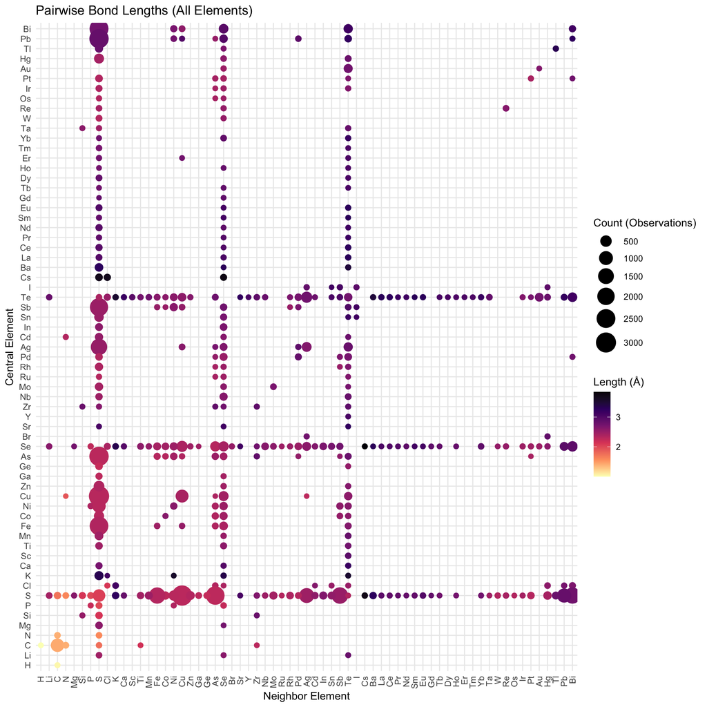

```r
pair_len_agg <- final_bonds_data[, .(MeanLength = mean(Distance), Count = .N),
                                 by = .(Element1, Z1, Element2, Z2)]
pair_len_agg <- pair_len_agg[Count >= 5]
pair_len_agg[, Element1 := fct_reorder(Element1, Z1)]
pair_len_agg[, Element2 := fct_reorder(Element2, Z2)]

p71 <- ggplot(pair_len_agg, aes(x = Element2, y = Element1,
                                text = paste("Center:", Element1, "<br>Neighbor:", Element2,
                                             "<br>Avg Dist:", round(MeanLength, 3), "Å",
                                             "<br>Count:", Count))) +
  geom_point(aes(size = Count, color = MeanLength)) +
  scale_color_viridis_c(option = "magma", direction = -1, name = "Length (Å)") +
  scale_size_continuous(range = c(2, 9), breaks = scales::breaks_pretty(n = 5), name = "Count (Observations)") +
  labs(title = "Pairwise Bond Lengths (All Elements)", x = "Neighbor Element", y = "Central Element") +
  theme_minimal() +
  theme(axis.text.x = element_text(angle = 90, vjust = 0.5, hjust = 1))

# 1. Static output for export (Preserves legend)
print(p71)
```

```r
# 2. Interactive output for exploration
ggplotly(p71, tooltip = "text")
```

[interactive chart not shown]

### 7.2 Pairwise Bond Angles

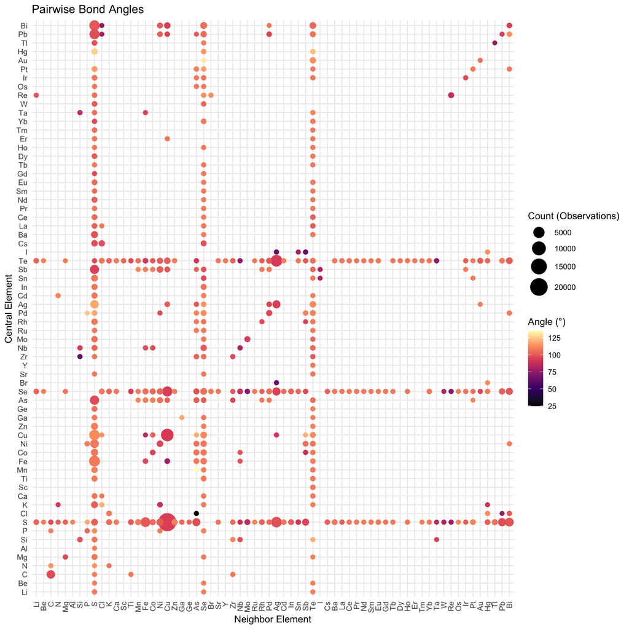

[interactive chart not shown]

```r
if (exists("all_angles_data") && nrow(all_angles_data) > 0) {
  df_angles <- copy(all_angles_data)
  if(!"Z1" %in% names(df_angles)) {
     df_angles[, Element1 := str_extract(CentralAtom, "^[A-Za-z]+")]
     df_angles[, Element2 := str_extract(Neighbor1, "^[A-Za-z]+")]
     df_angles <- merge(df_angles, ptable, by.x="Element1", by.y="Symbol", all.x=TRUE)
     setnames(df_angles, "Z", "Z1")
     df_angles <- merge(df_angles, ptable, by.x="Element2", by.y="Symbol", all.x=TRUE)
     setnames(df_angles, "Z", "Z2")
  }
  df_angles <- df_angles[!is.na(Z1) & !is.na(Z2)]

  pair_ang_agg <- df_angles[, .(MeanAngle = mean(Angle), Count = .N),
                            by = .(Element1, Z1, Element2, Z2)]
  pair_ang_agg <- pair_ang_agg[Count >= 5]
  pair_ang_agg[, Element1 := fct_reorder(Element1, Z1)]
  pair_ang_agg[, Element2 := fct_reorder(Element2, Z2)]

  p72 <- ggplot(pair_ang_agg, aes(x = Element2, y = Element1,
                                  text = paste("Center:", Element1, "<br>Neighbor:", Element2,
                                               "<br>Avg Angle:", round(MeanAngle, 1), "°",
                                               "<br>Count:", Count))) +
    geom_point(aes(size = Count, color = MeanAngle)) +
    scale_color_viridis_c(option = "magma", name = "Angle (°)") +
    scale_size_continuous(range = c(2, 9), breaks = scales::breaks_pretty(n = 5), name = "Count (Observations)") +
    labs(title = "Pairwise Bond Angles", x = "Neighbor Element", y = "Central Element") +
    theme_minimal() +
    theme(axis.text.x = element_text(angle = 90, vjust = 0.5, hjust = 1))

  # 1. Static output for export (Preserves legend)
  print(p72)

  # 2. Interactive output for exploration
  ggplotly(p72, tooltip = "text")
} else {
  cat("No bond angle data available.\n")
}
```

## 8. Coordination Number Analysis

### 8.1 Regular Geometric CN

Geometric CN counts exactly how many points exist within the bonding distance sphere, without considering partial occupancies.

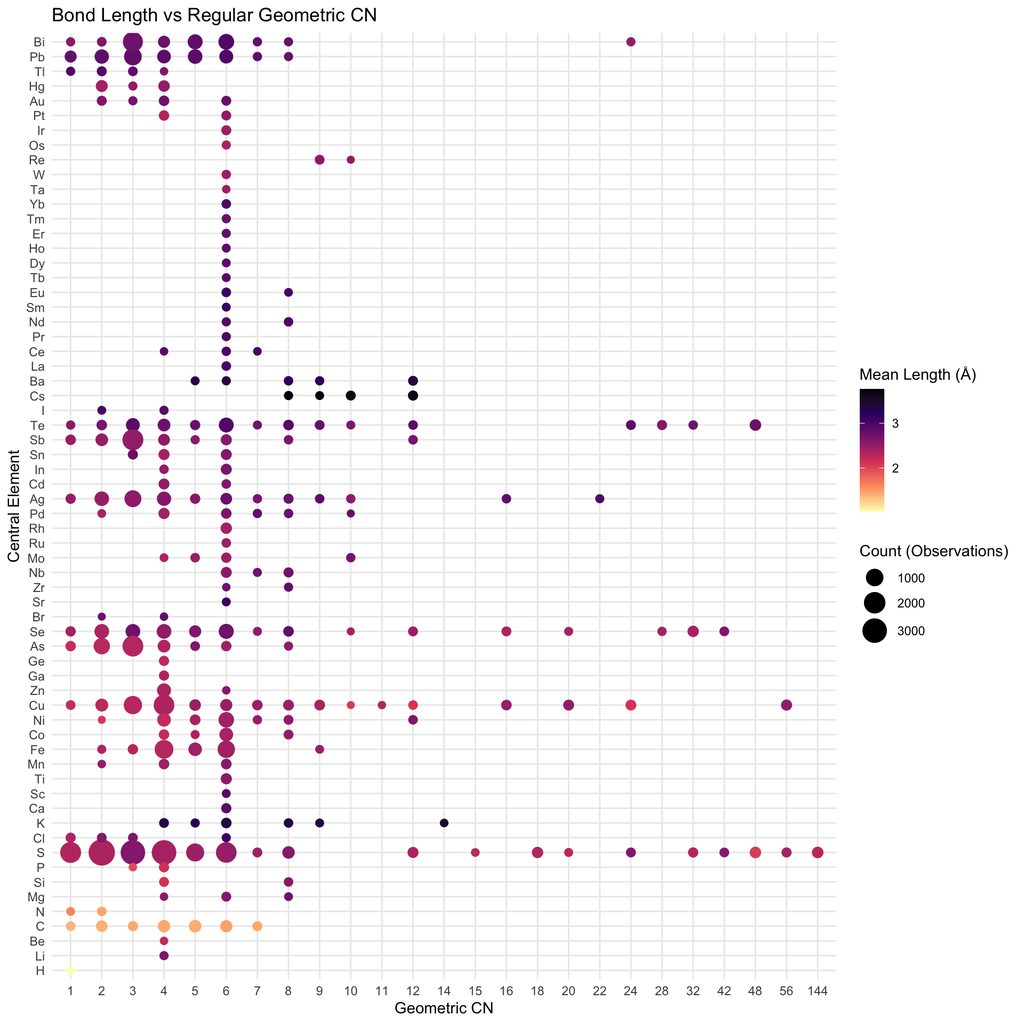

```r
reg_cn_agg <- final_bonds_data[, .(MeanLength = mean(Distance), Count = .N),
                               by = .(Element1, Z1, CoordinationNumber)]
reg_cn_agg <- reg_cn_agg[Count >= 10]
reg_cn_agg[, Element1 := fct_reorder(Element1, Z1)]

p81 <- ggplot(reg_cn_agg, aes(x = factor(CoordinationNumber), y = Element1,
                              text = paste("Element:", Element1, "<br>CN:", CoordinationNumber,
                                           "<br>Avg Dist:", round(MeanLength, 3), "Å",
                                           "<br>Count:", Count))) +
  geom_point(aes(size = Count, color = MeanLength)) +
  scale_color_viridis_c(option = "magma", direction = -1, name = "Mean Length (Å)") +
  scale_size_continuous(range = c(2, 8), breaks = scales::breaks_pretty(n = 5), name = "Count (Observations)") +
  labs(title = "Bond Length vs Regular Geometric CN", x = "Geometric CN", y = "Central Element") +
  theme_minimal()

# 1. Static
print(p81)
```

```r
# 2. Interactive
ggplotly(p81, tooltip = "text")
```

[interactive chart not shown]

### 8.2 Weighted CN

This view re-analyzes the data by adjusting for crystallographic site occupancies. High Geometric CN environments often condense down into standard values (e.g., highly disordered CN=24 environments condense to Weighted CN=6).

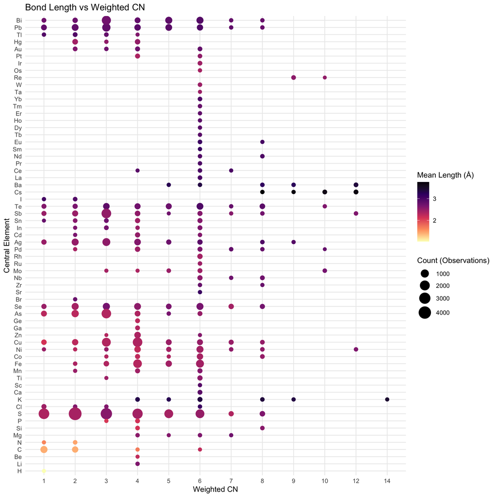

```r
wcn_agg <- final_bonds_data[, .(MeanLength = mean(Distance), Count = .N),
                            by = .(Element1, Z1, RoundedWeightedCN)]
wcn_agg <- wcn_agg[Count >= 10 & RoundedWeightedCN > 0]
wcn_agg[, Element1 := fct_reorder(Element1, Z1)]

p82 <- ggplot(wcn_agg, aes(x = factor(RoundedWeightedCN), y = Element1,
                           text = paste("Element:", Element1, "<br>W-CN:", RoundedWeightedCN,
                                        "<br>Avg Dist:", round(MeanLength, 3), "Å",
                                        "<br>Count:", Count))) +
  geom_point(aes(size = Count, color = MeanLength)) +
  scale_color_viridis_c(option = "magma", direction = -1, name = "Mean Length (Å)") +
  scale_size_continuous(range = c(2, 8), breaks = scales::breaks_pretty(n = 5), name = "Count (Observations)") +
  labs(title = "Bond Length vs Weighted CN", x = "Weighted CN", y = "Central Element") +
  theme_minimal()

# 1. Static
print(p82)
```

```r
# 2. Interactive
ggplotly(p82, tooltip = "text")
```

[interactive chart not shown]

### 8.3 Weighted CN (Sorted by Global Bond Length)

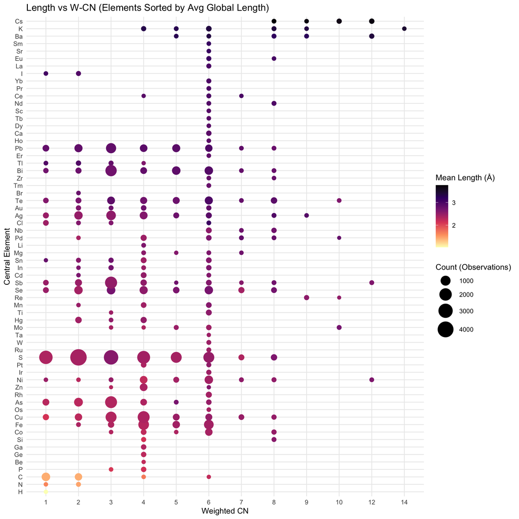

```r
wcn_agg_len <- copy(wcn_agg)
elem_means <- wcn_agg_len[, .(GlobalMean = mean(MeanLength)), by = Element1]
wcn_agg_len <- merge(wcn_agg_len, elem_means, by="Element1")
wcn_agg_len[, Element1 := fct_reorder(Element1, GlobalMean)]

p83 <- ggplot(wcn_agg_len, aes(x = factor(RoundedWeightedCN), y = Element1,
                               text = paste("Element:", Element1, "<br>W-CN:", RoundedWeightedCN,
                                            "<br>Avg Dist:", round(MeanLength, 3), "Å"))) +
  geom_point(aes(size = Count, color = MeanLength)) +
  scale_color_viridis_c(option = "magma", direction = -1, name = "Mean Length (Å)") +
  scale_size_continuous(range = c(2, 10), breaks = scales::breaks_pretty(n = 5), name = "Count (Observations)") +
  labs(title = "Length vs W-CN (Elements Sorted by Avg Global Length)", x = "Weighted CN", y = "Central Element") +
  theme_minimal()

# 1. Static
print(p83)
```

```r
# 2. Interactive
ggplotly(p83, tooltip = "text")
```

[interactive chart not shown]

## 9. Chalcogen-Specific Analysis

Filtering the entire dataset to place the Chalcogens (Sulfur, Selenium, Tellurium) strictly at the center of the geometric queries.

```r
targets <- c("S", "Se", "Te")
df_center_chalc <- final_bonds_data[Element1 %in% targets]
```

### 9.1 S, Se, Te: Bond Lengths

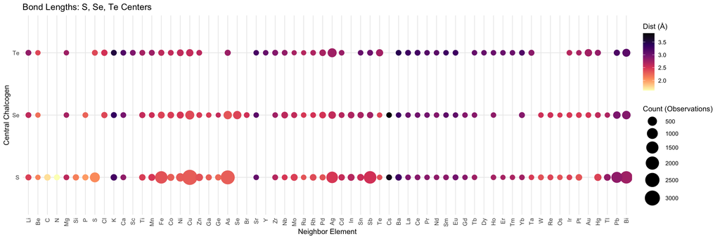

```r
agg_center <- df_center_chalc[, .(MeanDist = mean(Distance), N=.N), by=.(Element1, Z1, Element2, Z2)]
agg_center <- agg_center[N >= 3]
agg_center[, Element1 := fct_reorder(Element1, Z1)]
agg_center[, Element2 := fct_reorder(Element2, Z2)]

p91 <- ggplot(agg_center, aes(x = Element2, y = Element1,
                              text = paste("Center:", Element1, "<br>Neighbor:", Element2,
                                           "<br>Dist:", round(MeanDist, 3), "Å",
                                           "<br>Obs:", N))) +
  geom_point(aes(size = N, color = MeanDist)) +
  scale_color_viridis_c(option = "magma", direction = -1, name = "Dist (Å)") +
  scale_size_continuous(range = c(3, 10), breaks = scales::breaks_pretty(n = 5), name = "Count (Observations)") +
  labs(title = "Bond Lengths: S, Se, Te Centers", x = "Neighbor Element", y = "Central Chalcogen") +
  theme_minimal() +
  theme(axis.text.x = element_text(angle = 90, vjust = 0.5, hjust = 1))

# 1. Static
print(p91)
```

```r
# 2. Interactive
ggplotly(p91, tooltip = "text")
```

[interactive chart not shown]

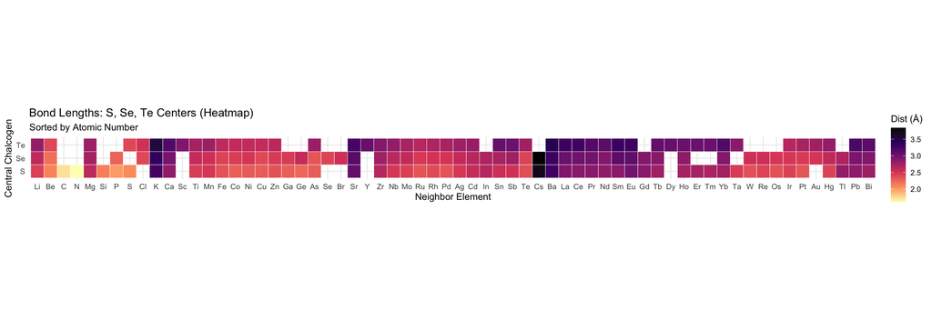

```r
# 3. Heatmap
ggplot(agg_center, aes(x = Element2, y = Element1, fill = MeanDist)) +
  geom_tile(color = "white") +
  scale_fill_viridis_c(option = "magma", direction = -1, name = "Dist (Å)") +
  labs(title = "Bond Lengths: S, Se, Te Centers (Heatmap)",
       subtitle = "Sorted by Atomic Number",
       x = "Neighbor Element", y = "Central Chalcogen") +
  theme_minimal() +
  coord_fixed()
```

### 9.2 S, Se, Te: Regular Geometric CN

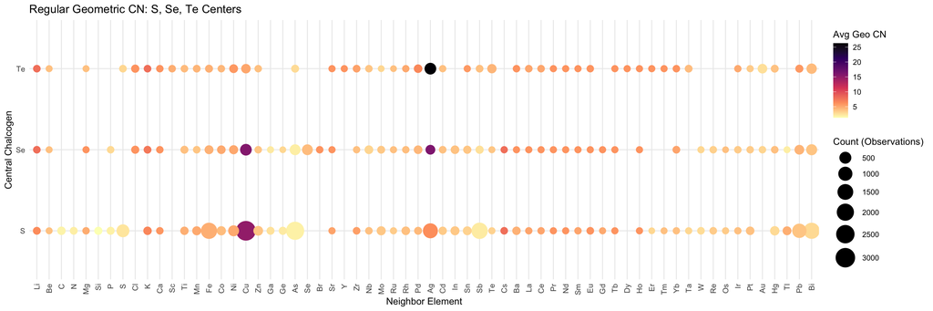

```r
agg_center_cn <- df_center_chalc[, .(MeanCN = mean(CoordinationNumber), N=.N),
                                 by=.(Element1, Z1, Element2, Z2)]
agg_center_cn <- agg_center_cn[N >= 3]
agg_center_cn[, Element1 := fct_reorder(Element1, Z1)]
agg_center_cn[, Element2 := fct_reorder(Element2, Z2)]

p92 <- ggplot(agg_center_cn, aes(x = Element2, y = Element1,
                                 text = paste("Center:", Element1, "<br>Neighbor:", Element2,
                                              "<br>Avg CN:", round(MeanCN, 1),
                                              "<br>Obs:", N))) +
  geom_point(aes(size = N, color = MeanCN)) +
  scale_color_viridis_c(option = "magma", direction = -1, name = "Avg Geo CN") +
  scale_size_continuous(range = c(3, 10), breaks = scales::breaks_pretty(n = 5), name = "Count (Observations)") +
  labs(title = "Regular Geometric CN: S, Se, Te Centers", x = "Neighbor Element", y = "Central Chalcogen") +
  theme_minimal() +
  theme(axis.text.x = element_text(angle = 90, vjust = 0.5, hjust = 1))

# 1. Static
print(p92)
```

```r
# 2. Interactive
ggplotly(p92, tooltip = "text")
```

[interactive chart not shown]

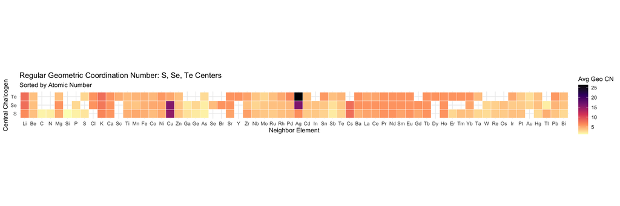

```r
# 3. Heatmap
ggplot(agg_center_cn, aes(x = Element2, y = Element1, fill = MeanCN)) +
  geom_tile(color = "white") +
  scale_fill_viridis_c(option = "magma", direction = -1, name = "Avg Geo CN") +
  labs(title = "Regular Geometric Coordination Number: S, Se, Te Centers",
       subtitle = "Sorted by Atomic Number",
       x = "Neighbor Element", y = "Central Chalcogen") +
  theme_minimal() +
  coord_fixed()
```

### 9.3 S, Se, Te: Weighted CN (Special Aggregation)

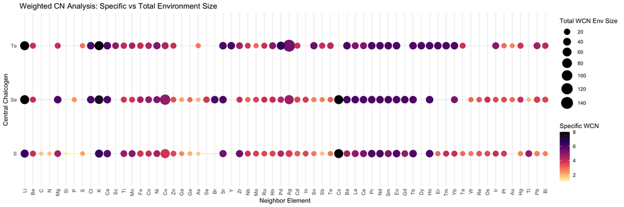

```r
# 1. Calculate Total Weighted CN per Central Atom
total_wcn_per_atom <- final_bonds_data[, .(Total_WCN = sum(CN_Weighted)), by = .(file_name, Atom1)]
plot_data_wcn <- merge(final_bonds_data, total_wcn_per_atom, by = c("file_name", "Atom1"))

# 2. Filter & Aggregate
df_plot <- plot_data_wcn[Element1 %in% targets]
agg_wcn_complex <- df_plot[, .(
  Avg_Specific_WCN = mean(CN_Weighted), # Color
  Avg_Total_WCN    = mean(Total_WCN),   # Size
  N                = .N
), by = .(Element1, Z1, Element2, Z2)]

agg_wcn_complex <- agg_wcn_complex[N >= 3]
agg_wcn_complex[, Element1 := fct_reorder(Element1, Z1)]
agg_wcn_complex[, Element2 := fct_reorder(Element2, Z2)]

p93 <- ggplot(agg_wcn_complex, aes(x = Element2, y = Element1,
                                   text = paste("Center:", Element1, "<br>Neighbor:", Element2,
                                                "<br>Specific WCN (Color):", round(Avg_Specific_WCN, 2),
                                                "<br>Total Env CN (Size):", round(Avg_Total_WCN, 2),
                                                "<br>Obs:", N))) +
  geom_point(aes(size = Avg_Total_WCN, color = Avg_Specific_WCN)) +
  scale_color_viridis_c(option = "magma", direction = -1, name = "Specific WCN") +
  scale_size_continuous(range = c(2, 9), breaks = scales::breaks_pretty(n = 5), name = "Total WCN Env Size") +
  labs(title = "Weighted CN Analysis: Specific vs Total Environment Size", x = "Neighbor Element", y = "Central Chalcogen") +
  theme_minimal() +
  theme(axis.text.x = element_text(angle = 90, vjust = 0.5, hjust = 1))

# 1. Static
print(p93)
```

```r
# 2. Interactive
ggplotly(p93, tooltip = "text")
```

[interactive chart not shown]

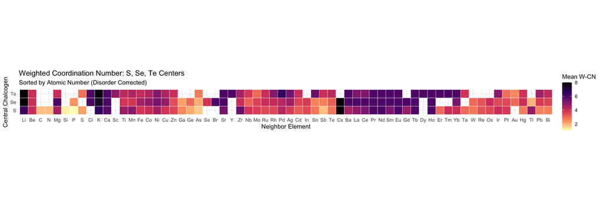

```r
# 3. Aggregate Heatmap
agg_center_wcn <- df_center_chalc[, .(MeanWCN = mean(CN_Weighted), N=.N),
                                  by=.(Element1, Z1, Element2, Z2)]
agg_center_wcn <- agg_center_wcn[N >= 3]

# Sort by Atomic Number (Z)
agg_center_wcn[, Element1 := fct_reorder(Element1, Z1)]
agg_center_wcn[, Element2 := fct_reorder(Element2, Z2)]

ggplot(agg_center_wcn, aes(x = Element2, y = Element1, fill = MeanWCN)) +
  geom_tile(color = "white") +
  scale_fill_viridis_c(option = "magma", direction = -1, name = "Mean W-CN") +
  labs(title = "Weighted Coordination Number: S, Se, Te Centers",
       subtitle = "Sorted by Atomic Number (Disorder Corrected)",
       x = "Neighbor Element", y = "Central Chalcogen") +
  theme_minimal() +
  coord_fixed()
```

## 10. Distribution Analysis

This visualization compares the distribution of bond lengths for the most common coordination numbers (e.g., 4 and 6), allowing us to see the “spread” of bond distances for specific elements.

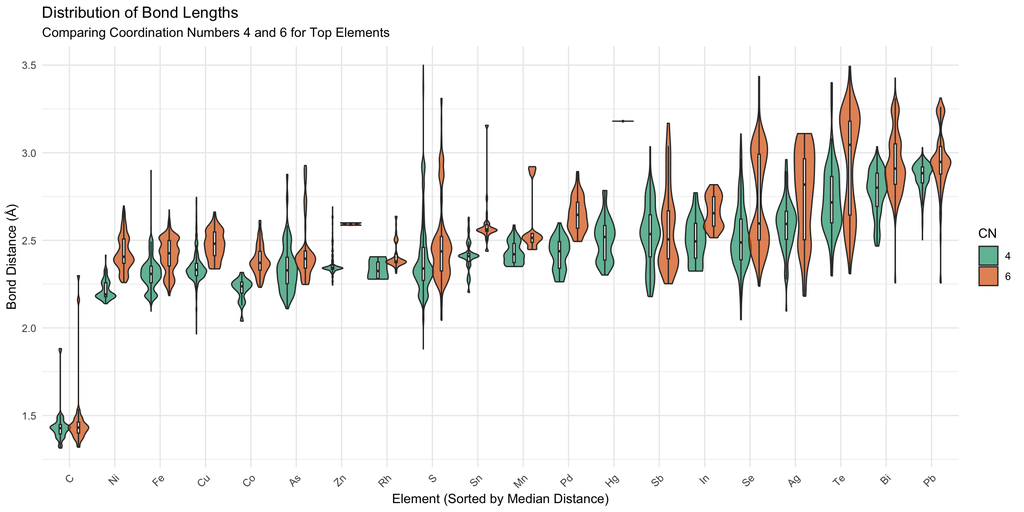

```r
# --- Distribution Analysis (Violin Plot) ---

# 1. Filter for common Coordination Numbers to make the plot readable
common_cns <- c(4, 6) # Focusing on Tetrahedral and Octahedral
violin_data <- final_bonds_data[CoordinationNumber %in% common_cns]

# 2. Filter to top 20 most frequent elements to keep the x-axis clean
top_elements <- violin_data[, .N, by = Element1][order(-N)][1:20, Element1]
violin_data <- violin_data[Element1 %in% top_elements]

# 3. Plot
ggplot(violin_data, aes(x = reorder(Element1, Distance), y = Distance)) +
  geom_violin(aes(fill = factor(CoordinationNumber)), scale = "width", alpha = 0.7, position = position_dodge(width = 0.8)) +
  geom_boxplot(aes(group = interaction(Element1, CoordinationNumber)),
               width = 0.1, outlier.shape = NA, fill="white", position = position_dodge(width = 0.8)) +
  scale_fill_brewer(palette = "Dark2", name = "CN") +
  labs(title = "Distribution of Bond Lengths",
       subtitle = "Comparing Coordination Numbers 4 and 6 for Top Elements",
       x = "Element (Sorted by Median Distance)",
       y = "Bond Distance (Å)") +
  theme_minimal() +
  theme(axis.text.x = element_text(angle = 45, hjust = 1))
```

## 11. Advanced: Length vs Angle (Grouped by Neighbor Family)

Faceted by S, Se, Te. Neighbors are colored by **standard IUPAC periodic table groups** (Alkali metals, Reactive nonmetals, Lanthanides, etc.), while explicitly preserving the requested split between **Early TMs** and **Late TMs**.

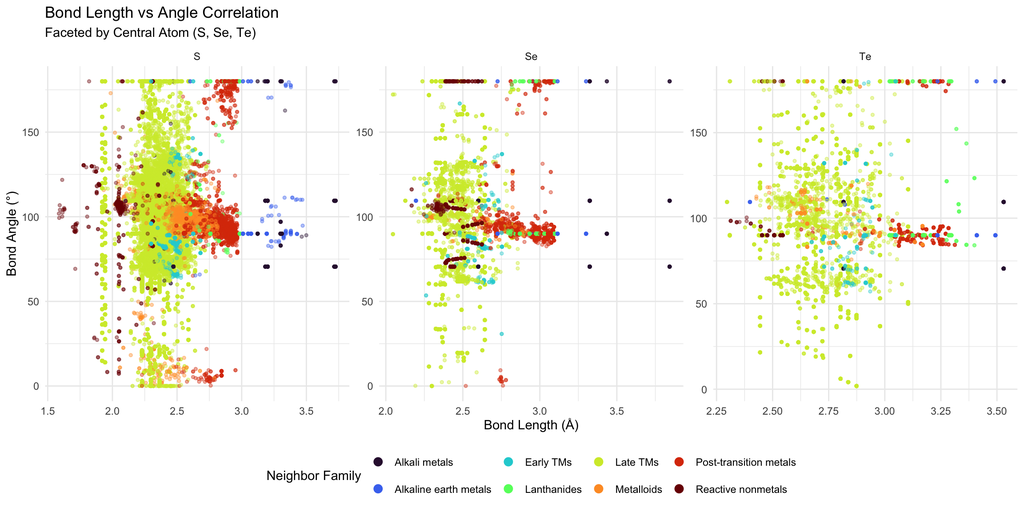

[interactive chart not shown]

```r
# --- 1. Expanded Group Metadata ---
extended_groups <- data.table(
  Symbol = c(
    # Alkali metals
    "Li", "Na", "K", "Rb", "Cs", "Fr",
    # Alkaline earth metals
    "Be", "Mg", "Ca", "Sr", "Ba", "Ra",
    # Early TMs
    "Sc", "Y", "Ti", "Zr", "Hf", "V", "Nb", "Ta", "Cr", "Mo", "W",
    # Late TMs
    "Mn", "Tc", "Re", "Fe", "Ru", "Os", "Co", "Rh", "Ir", "Ni", "Pd", "Pt", "Cu", "Ag", "Au", "Zn", "Cd", "Hg",
    # Post-transition metals
    "Al", "Ga", "In", "Tl", "Sn", "Pb", "Bi", "Po",
    # Metalloids
    "B", "Si", "Ge", "As", "Sb", "Te", "At",
    # Reactive nonmetals
    "H", "C", "N", "P", "O", "S", "Se", "F", "Cl", "Br", "I",
    # Noble gases
    "He", "Ne", "Ar", "Kr", "Xe", "Rn",
    # Lanthanides
    "La", "Ce", "Pr", "Nd", "Pm", "Sm", "Eu", "Gd", "Tb", "Dy", "Ho", "Er", "Tm", "Yb", "Lu",
    # Actinides
    "Ac", "Th", "Pa", "U", "Np", "Pu", "Am", "Cm", "Bk", "Cf", "Es", "Fm", "Md", "No", "Lr",
    # Unknown properties
    "Rf", "Db", "Sg", "Bh", "Hs", "Mt", "Ds", "Rg", "Cn", "Nh", "Fl", "Mc", "Lv", "Ts", "Og"
  ),
  GroupLabel = c(
    rep("Alkali metals", 6),
    rep("Alkaline earth metals", 6),
    rep("Early TMs", 11),
    rep("Late TMs", 18),
    rep("Post-transition metals", 8),
    rep("Metalloids", 7),
    rep("Reactive nonmetals", 11),
    rep("Noble gases", 6),
    rep("Lanthanides", 15),
    rep("Actinides", 15),
    rep("Unknown properties", 15)
  )
)

if (exists("all_angles_data") && nrow(all_angles_data) > 0) {
  # A. Filter Angles for S, Se, Te centers ONLY
  target_centers <- c("S", "Se", "Te")
  # Filter using regex to catch isotopes/labels but stricter check later
  df_angles_sub <- all_angles_data[CentralAtom %like% "^(S|Se|Te)([0-9]|$|_)"]

  # Extract Base Symbols
  df_angles_sub[, CenterSym := str_extract(CentralAtom, "^[A-Za-z]+")]
  df_angles_sub[, NeighborSym := str_extract(Neighbor1, "^[A-Za-z]+")]

  # Strict filter to keep only S, Se, Te
  df_angles_sub <- df_angles_sub[CenterSym %in% target_centers]

  # B. Prepare Bonds for Distance merging
  unique_bonds <- unique(final_bonds_data[, .(file_name, Atom1, Atom2, Distance)], by = c("file_name", "Atom1", "Atom2"))

  # C. Merge Angle + Distance
  plot_data <- merge(
    df_angles_sub,
    unique_bonds,
    by.x = c("file_name", "CentralAtom", "Neighbor1"),
    by.y = c("file_name", "Atom1", "Atom2"),
    allow.cartesian = TRUE
  )

  # D. Merge Neighbor Group Info
  plot_data <- merge(
    plot_data,
    extended_groups,
    by.x = "NeighborSym",
    by.y = "Symbol",
    all.x = TRUE
  )

  # Remove NAs (elements not in our group list)
  plot_data <- plot_data[!is.na(GroupLabel)]

  # E. Sort Central Atom for Plotting Order
  plot_data[, CenterSym := factor(CenterSym, levels = c("S", "Se", "Te"))]

  # --- 3. Plotting ---
  p11 <- ggplot(plot_data, aes(
    x = Distance,
    y = Angle,
    text = paste(
      "Center:", CentralAtom,
      "<br>Neighbor:", Neighbor1,
      "<br>Group:", GroupLabel
    )
  )) +
    geom_point(aes(color = GroupLabel), alpha = 0.4, size = 1) +
    facet_wrap( ~ CenterSym, scales = "free", ncol = 3) +
    scale_color_viridis_d(option = "turbo", name = "Neighbor Family") +
    labs(
      title = "Bond Length vs Angle Correlation",
      subtitle = "Faceted by Central Atom (S, Se, Te)",
      x = "Bond Length (Å)",
      y = "Bond Angle (°)"
    ) +
    theme_minimal() +
    theme(legend.position = "bottom") +
    guides(color = guide_legend(override.aes = list(alpha = 1, size = 3)))

  # 1. Static
  print(p11)

  # 2. Interactive (toWebGL helps performance with 10k+ points)
  toWebGL(ggplotly(p11, tooltip = "text")) %>%
    layout(legend = list(orientation = "h", x = 0, y = -0.2))

} else {
  cat("No angle data available to plot.\n")
}
```